# REVIEW INTERMEDIATE R: CONDITIONALS & CONTROL FLOW

### 1. Grade analysis in R

Suppose you’re a student in a class with other 199 classmates. You want to analyze the grades of this academy. The highest possible grade is 100, the lowest possible grade is 0.

You know your own grade.

```r
me <- 89
```

You have the access to the anonymized grades of other students.

```r
other_199 <- scan("other_199.txt")
```

You also have the access to the grades of previous 4 years. Import this data and convert it into a matrix with 4 columns:

```r
previous_4 <- matrix(scan("previous_4.txt"), ncol = 4)
head(previous_4)
```

```
##      [,1] [,2] [,3] [,4]
## [1,]   82   90   97   88
## [2,]   89   83   96   72
## [3,]   53   87   79   74
## [4,]   70   65   74   76
## [5,]   66   68   96   65
## [6,]   89   77   79   76
```

To format the data so that it would be easier to work with and analyze later on, merge the three datasets:

```r
my_class <- c(me, other_199)
```

Build a 200x5 matrix using `cbind()` to merge columns:

```r
last_5 <- cbind(my_class, previous_4)
```

Name `last_5` appropriately from year_1 to year_5:

```r
colnames(last_5) <- paste0("year_", 1:5)
```

`paste0()` uses an empty string to join strings.

### 2. Explore your data

To get a good feel for your data, it is a good idea to make some visualizations and make some summaries.

Build a histogram to have an overview of the grade this year:

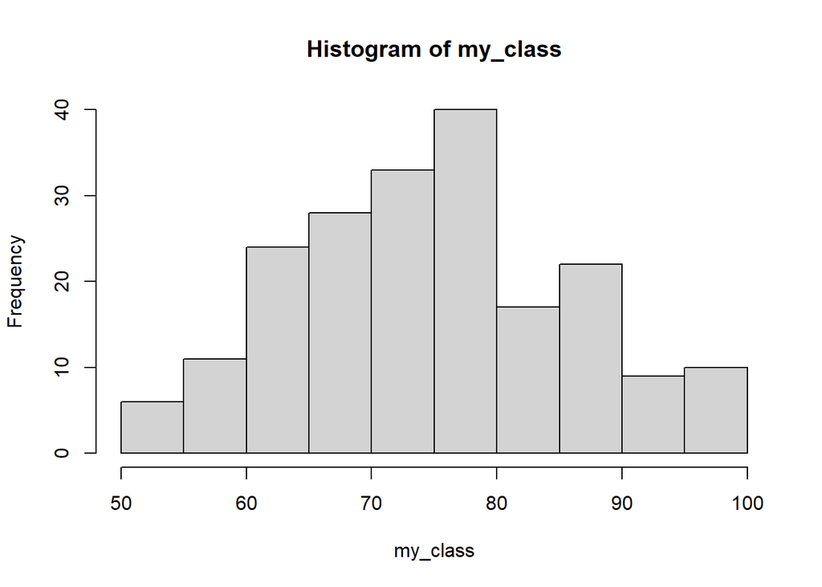

```r
hist(my_class) # your grade (89) is in the 85-90 bin.
```

Distinguish different bars with different colors:

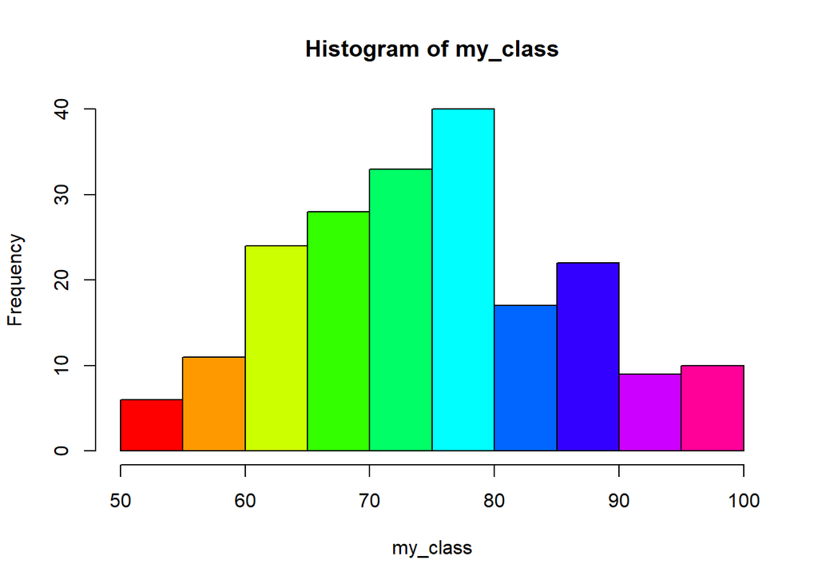

```r
hist(my_class, col = rainbow(10)) # use rainbow palette.
```

Generate a summary of each year:

```r
summary(last_5)
```

```
##      year_1           year_2          year_3           year_4
##  Min.   : 50.00   Min.   : 50.0   Min.   : 50.00   Min.   :50.00
##  1st Qu.: 68.00   1st Qu.: 67.0   1st Qu.: 65.00   1st Qu.:69.00
##  Median : 75.00   Median : 75.0   Median : 73.00   Median :76.00
##  Mean   : 75.52   Mean   : 75.8   Mean   : 74.57   Mean   :75.34
##  3rd Qu.: 82.00   3rd Qu.: 85.0   3rd Qu.: 85.00   3rd Qu.:84.25
##  Max.   :100.00   Max.   :100.0   Max.   :100.00   Max.   :99.00
##      year_5
##  Min.   : 50.00
##  1st Qu.: 67.00
##  Median : 75.00
##  Mean   : 75.00
##  3rd Qu.: 82.25
##  Max.   :100.00
```

A boxplot is more informative here.

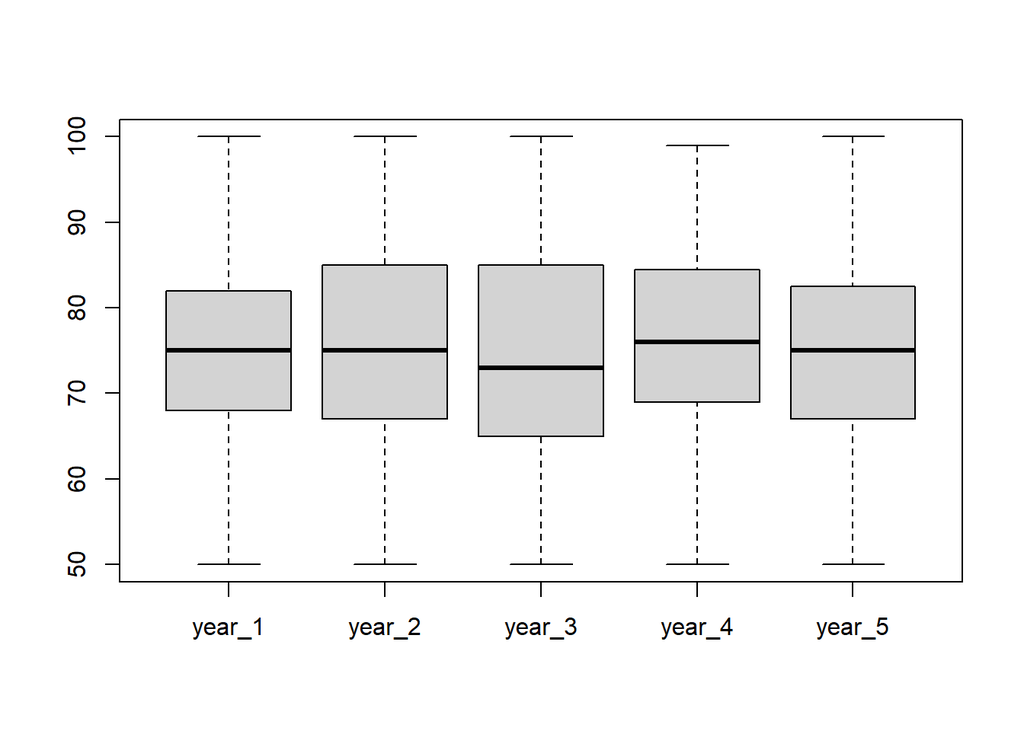

```r
boxplot(last_5)
```

The plot shows only a slight difference among 5 years.

### 3. Basic queries

Using relational operators to write queries to answer question about `me`, `my_class` and `last_5`.

Is your grade equal to 72?

```r
me == 72
```

```
## [1] FALSE
```

Which grades in your class are higher than 75?

```r
my_class > 75
```

```
##   [1]  TRUE FALSE  TRUE  TRUE  TRUE  TRUE FALSE  TRUE  TRUE  TRUE FALSE  TRUE
##  [13] FALSE  TRUE FALSE FALSE  TRUE FALSE FALSE FALSE  TRUE  TRUE  TRUE  TRUE
##  [25]  TRUE  TRUE  TRUE  TRUE FALSE FALSE FALSE  TRUE  TRUE  TRUE  TRUE FALSE
##  [37] FALSE  TRUE FALSE FALSE FALSE FALSE  TRUE  TRUE FALSE FALSE FALSE FALSE
##  [49] FALSE FALSE  TRUE FALSE  TRUE  TRUE FALSE FALSE FALSE FALSE  TRUE  TRUE
##  [61] FALSE  TRUE FALSE FALSE FALSE  TRUE FALSE  TRUE  TRUE  TRUE  TRUE  TRUE
##  [73]  TRUE  TRUE FALSE FALSE FALSE FALSE FALSE FALSE FALSE FALSE  TRUE  TRUE
##  [85]  TRUE FALSE  TRUE  TRUE  TRUE  TRUE FALSE FALSE  TRUE FALSE  TRUE FALSE
##  [97] FALSE  TRUE FALSE FALSE  TRUE FALSE FALSE FALSE  TRUE FALSE  TRUE  TRUE
## [109] FALSE  TRUE FALSE  TRUE FALSE FALSE  TRUE  TRUE FALSE  TRUE  TRUE FALSE
## [121]  TRUE  TRUE FALSE FALSE FALSE FALSE  TRUE FALSE FALSE FALSE  TRUE  TRUE
## [133]  TRUE  TRUE  TRUE  TRUE  TRUE  TRUE  TRUE  TRUE  TRUE FALSE  TRUE FALSE
## [145] FALSE  TRUE FALSE FALSE FALSE FALSE  TRUE  TRUE FALSE FALSE FALSE FALSE
## [157] FALSE FALSE FALSE FALSE FALSE FALSE FALSE  TRUE FALSE FALSE  TRUE  TRUE
## [169] FALSE  TRUE FALSE  TRUE FALSE  TRUE  TRUE  TRUE  TRUE FALSE  TRUE  TRUE
## [181] FALSE  TRUE FALSE  TRUE FALSE FALSE FALSE FALSE FALSE  TRUE  TRUE FALSE
## [193] FALSE  TRUE  TRUE  TRUE FALSE  TRUE  TRUE FALSE
```

Which grades in the last 5 years are below or equal to 64?

```r
last_5 <= 64
```

```
##        year_1 year_2 year_3 year_4 year_5
##   [1,]  FALSE  FALSE  FALSE  FALSE  FALSE
##   [2,]  FALSE  FALSE  FALSE  FALSE  FALSE
##   [3,]  FALSE   TRUE  FALSE  FALSE  FALSE
##   [4,]  FALSE  FALSE  FALSE  FALSE  FALSE
##   [5,]  FALSE  FALSE  FALSE  FALSE  FALSE
##   [6,]  FALSE  FALSE  FALSE  FALSE  FALSE
##   [7,]   TRUE  FALSE  FALSE   TRUE  FALSE
##   [8,]  FALSE  FALSE  FALSE  FALSE  FALSE
##   [9,]  FALSE  FALSE   TRUE   TRUE  FALSE
##  [10,]  FALSE  FALSE  FALSE  FALSE   TRUE
##  [11,]  FALSE  FALSE  FALSE  FALSE  FALSE
##  [12,]  FALSE  FALSE  FALSE  FALSE  FALSE
##  [13,]  FALSE  FALSE  FALSE  FALSE  FALSE
##  [14,]  FALSE  FALSE  FALSE  FALSE  FALSE
```

[output cut: 186 more lines]

The result of the queries should be a vector or a matrix of logicals.

### 4. Logical operator

Next to relational operators, there are also logical operators, to combine logicals: `&` - AND, `|` - OR, `!` - NOT.

Is your grade greater than 87 and smaller than or equal to 89?

```r
me > 87 & me <= 89
```

```
## [1] TRUE
```

Which grades in your class are below 60 or above 90?

```r
my_class < 60 | my_class >90
```

```
##   [1] FALSE FALSE FALSE FALSE FALSE  TRUE  TRUE FALSE FALSE FALSE FALSE  TRUE
##  [13] FALSE FALSE FALSE FALSE  TRUE FALSE  TRUE FALSE  TRUE FALSE FALSE FALSE
##  [25]  TRUE FALSE FALSE FALSE FALSE FALSE FALSE  TRUE  TRUE FALSE FALSE  TRUE
##  [37] FALSE FALSE FALSE FALSE FALSE FALSE FALSE FALSE FALSE FALSE FALSE FALSE
##  [49] FALSE FALSE FALSE  TRUE FALSE FALSE FALSE FALSE FALSE FALSE FALSE FALSE
##  [61] FALSE FALSE  TRUE FALSE FALSE FALSE FALSE FALSE FALSE FALSE FALSE FALSE
##  [73] FALSE FALSE  TRUE FALSE FALSE FALSE FALSE FALSE FALSE FALSE FALSE FALSE
##  [85] FALSE FALSE FALSE  TRUE FALSE FALSE FALSE FALSE FALSE FALSE FALSE FALSE
##  [97] FALSE FALSE  TRUE FALSE FALSE FALSE FALSE FALSE  TRUE FALSE FALSE  TRUE
## [109] FALSE FALSE FALSE  TRUE FALSE  TRUE  TRUE FALSE FALSE FALSE  TRUE FALSE
## [121] FALSE FALSE FALSE FALSE FALSE FALSE  TRUE FALSE  TRUE FALSE FALSE FALSE
## [133] FALSE FALSE FALSE FALSE FALSE FALSE FALSE  TRUE FALSE FALSE FALSE  TRUE
## [145] FALSE FALSE FALSE FALSE  TRUE FALSE FALSE FALSE FALSE FALSE FALSE FALSE
## [157] FALSE FALSE FALSE FALSE FALSE FALSE FALSE FALSE FALSE FALSE FALSE FALSE
## [169] FALSE FALSE FALSE FALSE FALSE FALSE FALSE FALSE FALSE FALSE FALSE FALSE
## [181] FALSE FALSE FALSE FALSE FALSE FALSE FALSE FALSE FALSE  TRUE  TRUE FALSE
## [193] FALSE  TRUE FALSE  TRUE FALSE FALSE FALSE FALSE
```

### 5. Build aggregates

Answering the question which grades in your class are higher than 75 with a vector of logicals is not very insightful. It’s much better to ask the question how many grades in your class are higher than 75 instead.

For a logical vector, each `TRUE` counts as **1**, and each `FALSE` — as **0**. So summing all the elements of a logical vector is equivalent to counting all the **1**’s (i.e. counting all the `TRUE` values).

How many grades in your class are higher than 75?

```r
sum(my_class > 75)
```

```
## [1] 98
```

How many students in your class scored strictly higher than you?

```r
sum(my_class > me)
```

```
## [1] 27
```

Just in the same way, use `mean()` to find proportion of `TRUE` values in a logical vector: `mean()` returns the number of `TRUE` values divided by the total number of values.

What’s the proportion of grades below or equal to 64 in the last 5 years?

```r
mean(last_5 <= 64)
```

```
## [1] 0.201
```

What’s the proportion of grades in your class that are greater than or equal to 70 and lower than or equal to 85?

```r
mean(my_class >= 70 & my_class <= 85)
```

```
## [1] 0.515
```

How many students in the last 5 years had a grade of 80 or 90?

```r
sum(last_5 == 80 | last_5 == 90)
```

```
## [1] 86
```

### 6. if, else

Recall the syntax of `if-else`:

```r
if (me > 80) {
  print("Good student!")
} else {
  print("Better luck nex year!")
}
```

```
## [1] "Good student!"
```

Your grade (me) = 89, so the condition in the if statement evaluates to `TRUE`, and print(“Good student!”) is executed.

Assign to `n_smart` the number of grades in `my_class` that are greater than or equal to 80.

```r
n_smart <- sum(my_class >= 80)
```

Write an `if-else` statement:

```r
if (n_smart > 50) {
  print("smart class")
} else {
  print("rather average")
}
```

```
## [1] "smart class"
```

### 7. else if

Assign prop_less the proportion of students whose grade - stored in `my_class` - was lower than yours:

```r
prop_less <- mean(my_class < me)
```

Customize further the `if-else` constructs with `else if` statement:

```r
if (prop_less > 0.9) {
  print("you're among the best 10 percent")
} else if (prop_less > 0.8) {
  print("you're among the best 20 percent")
} else {
  print("need more analysis")
}
```

```
## [1] "you're among the best 20 percent"
```

Imbedded if-else clauses:

```r
if (mean(my_class) < 75) {
  if (mean(my_class) > me) {
    print("average year, but still smarter than me")
  } else {
    print("average year, but I'm not that bad")
  }
} else {
  if (mean(my_class) > me) {
    print("smart year, even smarter than me")
  } else {
    print("smart year, but I am smarter")
  }
}
```

```
## [1] "smart year, but I am smarter"
```

```r
top_grades <- my_class[my_class >= 85]
worst_grades <- my_class[my_class < 65]
if (sum(top_grades) > sum(worst_grades)) {
  print("top grades prevail")
}
```

```
## [1] "top grades prevail"
```